# Week 06: Hypothesis testing

```r
library(tidyverse)
```

## Hypothesis testing

Our null hypothesis is: minor allele frequencies are the same everywhere on chromosome 6 Our alternative hypothesis: some places have higher minor allele frequencies than expected (balancing selection)

#### Load data and calculate maf

```r
d = read_delim(file="1000g.allele.frequencies.tsv.gz",delim=c("\t"))
```

#### For all snps calculate a “bin25k” variable based on position, each bin should be 25 kb

```r
d = d %>%
    mutate(bin25k = position %/% 25000) %>%
    ungroup()
```

Checkpoint

`names(d)`

[1] “position” “reference_allele” “alternative_allele” “population” “frequency” “maf” “bin25k”

`d %>% head(3)`

1 63979 C T EUR 0.1044 0.1044 2

2 63980 A G EUR 0.1044 0.1044 2

3 73938 A G EUR 0.0010 0.0010 2

For each bin calculate number of snps with maf > 0.2 (n20) , number of snps (n) , a test statistic (ts) = n20/n

Also calculate the position of the bin midpoint (x)

Call the binned results (1 row pr bin) for “br” (binned results)

```r
br = d %>%
  group_by(bin25k) %>%
  summarize(n20 = sum(maf>0.2),
            n   = n(),
            ts  = n20/n,
            x = (min(position)+max(position))/2) %>%
  ungroup()
```

Checkpoint

`names(br)`

[1] “bin25k” “n20” “n” “ts” “x”

`br %>% head(5)`

1 2 0 3 0.0000000 68958.5

2 3 0 2 0.0000000 88089.0

3 4 0 7 0.0000000 111903.5

4 5 1 7 0.1428571 146700.5

5 6 2 25 0.0800000 162538.5

#### Q: Plot this teststatistic along the chromosome and also visualise the number of snps in each bin

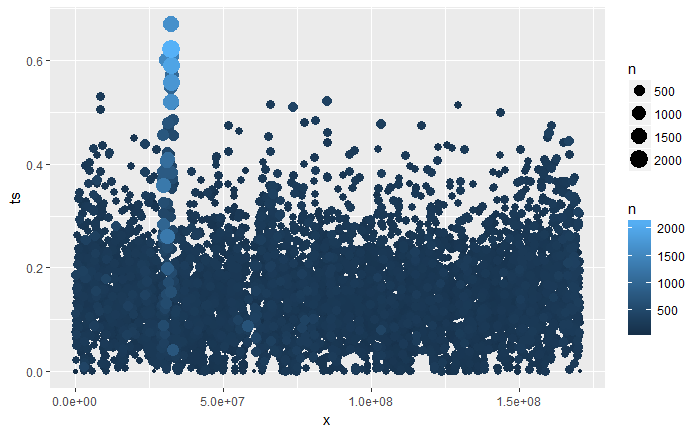

```r
pd = br %>% arrange(n)
plot1 = ggplot(data = pd, aes(x=x, y=ts, color=n, size=n)) +
  geom_point()  #+
  #scale_color_gradientn(colours = parula_colors)+
  #nature_theme()
ggsave(filename = "chromosome.plot.png", plot = plot1, width=100, height=60, units = "mm", dpi=300)
plot1
```

#### Q: What is the observed p20 = n20/n for the entire chromosome

```r
prob20[[1, 3]]
```

```
[1] 0.1583499
```

A: 0.1583499

## Continuing from last week

#### Q: select the best/easiest way of tesing if the observed proportion of SNPs with maf > 0.2 in the bin (0.1583499) is higher than expected

Our null hypothesis is: minor allele frequencies are the same everywhere on chromosome 6

Our alternative hypothesis: some places have higher minor allele frequencies than expected (balancing selection)

```r
binom <- br %>%
    ungroup() %>%
    rowwise() %>%
    mutate(p = sum(dbinom(n20:n, n, prob = 0.1583499)),
           p2 = pbinom(n20-1, size = n, prob = 0.1583499, lower.tail = F))
```

#### Q: List the 10 most significant bins

| bin25k | n20 | n | ts | x | p | p2 |
| --- | --- | --- | --- | --- | --- | --- |
| 1253 | 933 | 1553 | 0.6007727 | 31337517 | 0.000000e+00 | 0.000000e+00 |
| 1301 | 874 | 1432 | 0.6103352 | 32537557 | 0.000000e+00 | 0.000000e+00 |
| 1302 | 1109 | 1657 | 0.6692818 | 32562478 | 0.000000e+00 | 0.000000e+00 |
| 1305 | 1328 | 2138 | 0.6211413 | 32637448 | 0.000000e+00 | 0.000000e+00 |
| 1306 | 1145 | 1942 | 0.5895984 | 32662512 | 0.000000e+00 | 0.000000e+00 |
| 1304 | 973 | 1743 | 0.5582329 | 32612502 | 3.042950e-319 | 3.042950e-319 |
| 1307 | 827 | 1359 | 0.6085357 | 32687524 | 5.480642e-309 | 5.480642e-309 |
| 1303 | 846 | 1627 | 0.5199754 | 32587491 | 9.896233e-249 | 9.896233e-249 |
| 1300 | 713 | 1369 | 0.5208181 | 32512632 | 1.678120e-210 | 1.678120e-210 |
| 1308 | 609 | 1065 | 0.5718310 | 32712492 | 4.933865e-208 | 4.933865e-208 |

#### What is the lowest pvalue?

```r
binom %>%
    select(p) %>%
    min()
```

```
[1] 0
```

#### How many of your bins have p < 0.001?

```r
binom %>%
    filter(p < 0.001) %>%
    nrow()
```

```
[1] 853
```

#### If all bins followed H0: how many would you expect to have p < 0.001

```r
nrow(br) * 0.001
```

```
[1] 6.709
```

#### Q: Plot the p value as function of bin position

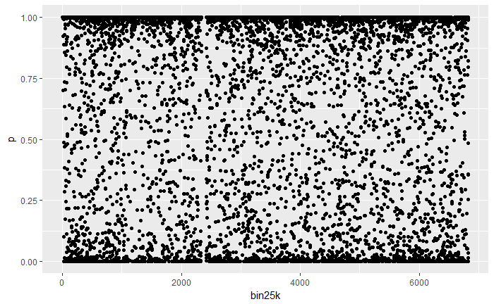

```r
ggplot(binom, aes(bin25k, p)) +
    geom_point()
```

#### Q: It is really difficult to see the small pvalues - try to mutate a new pvalue2 = -log10(pvalue) and plot it

This is called a Manhattan plot - strong signals will be skycrapers of significance

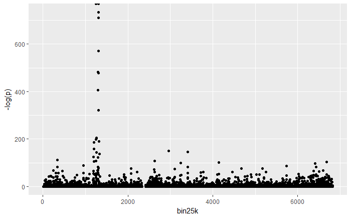

```r
ggplot(binom.test, aes(bin25k, -log(p))) +
    geom_point()
```

#### Q: Do you see a skyscraper?

YES

## Dividing the chromosome into bins with same number of snps

#### Q: Do the same analysis as before but using bins of size 500 snps instead

HINT:

`d %>% arrange(position) %>% mutate(SNPnumber = row_number())`

```r
d = d %>%
  arrange(position) %>%
  mutate(SNPnumber = row_number(), bin500snps = (SNPnumber-1) %/% 500)
```

[output not shown]

## Testing a specific hypothesis

Assume that I speculate that the overall frequency of SNPs with maf > 0.05 is really 50% in humans. NOTE: maf > 0.05 - I call these “high maf snps” Can you test if some bins of size 100 kb have significantly more high maf SNPs? Visualize the test results so it is easy to see where significant bins HINT: Make manhattan plots but also try and remove all bins with less than 50% of the snps having maf > 0.05

## Bonus question

#### Can you repeat the final test for all three populations?

#### Do you see a difference between the populations?